# metaG_CF_2_copy

```r
#plot(finish.denit.dbplsr.co2)
```

PERMANOVA:

```r
#Make metaG sample ID's the rownames on 'design'. Then drop design$Sample:
rownames(design) <- design$Sample
design <- design[,2:4]

# Make data frames from gene set relative abundance (RA) files and design
denitRA_design <- cbind(design, denitRA)
methRA_design <- cbind(design, methRA)
carb_metabRA_design <- cbind(design, carb_metabRA)
cytoCoxRA_design <- cbind(design, cytoCoxRA)

#PERMANOVA:
adonis_denit_interaction = adonis(denitRA_design[,-c(1:3)]~Treat*Hist*Plant, method = "bray", data = denitRA_design, perm=10000) #Testing 10,000 permutations
adonis_denit_interaction # Did not take much longer to run, but P-values are nearly equal
```

```
##
## Call:
## adonis(formula = denitRA_design[, -c(1:3)] ~ Treat * Hist * Plant,      data = denitRA_design, permutations = 10000, method = "bray")
##
## Permutation: free
## Number of permutations: 10000
##
## Terms added sequentially (first to last)
##
##                  Df SumsOfSqs    MeanSqs  F.Model       R2 Pr(>F)
## Treat             2  0.011674  0.0058372  1.01090  0.10577 0.4325
## Hist              1 -0.000026 -0.0000265 -0.00458 -0.00024 0.9923
## Plant             1  0.001662  0.0016622  0.28786  0.01506 0.8955
## Treat:Hist        2  0.003892  0.0019458  0.33697  0.03526 0.9556
## Treat:Plant       1  0.001757  0.0017565  0.30420  0.01591 0.8908
## Hist:Plant        1  0.002940  0.0029401  0.50917  0.02664 0.7447
## Treat:Hist:Plant  1  0.007634  0.0076342  1.32210  0.06917 0.2644
## Residuals        14  0.080840  0.0057743           0.73243
## Total            23  0.110372                      1.00000
```

```r
adonis_denit_main = adonis(denitRA_design[,-c(1:3)]~Treat+Hist+Plant, method = "bray", data = denitRA_design, perm=10000)
adonis_denit_main
```

```
##
## Call:
## adonis(formula = denitRA_design[, -c(1:3)] ~ Treat + Hist + Plant,      data = denitRA_design, permutations = 10000, method = "bray")
##
## Permutation: free
## Number of permutations: 10000
##
## Terms added sequentially (first to last)
##
##           Df SumsOfSqs    MeanSqs  F.Model       R2 Pr(>F)
## Treat      2  0.011674  0.0058372  1.14264  0.10577 0.3287
## Hist       1 -0.000026 -0.0000265 -0.00518 -0.00024 0.9924
## Plant      1  0.001662  0.0016622  0.32537  0.01506 0.8783
## Residuals 19  0.097062  0.0051085           0.87941
## Total     23  0.110372                      1.00000
```

```r
adonis_meth_interactive = adonis(methRA_design[,-c(1:3)]~Treat*Hist*Plant, method = "bray", data = methRA_design, perm=10000)
adonis_meth_interactive
```

```
##
## Call:
## adonis(formula = methRA_design[, -c(1:3)] ~ Treat * Hist * Plant,      data = methRA_design, permutations = 10000, method = "bray")
##
## Permutation: free
## Number of permutations: 10000
##
## Terms added sequentially (first to last)
##
##                  Df SumsOfSqs   MeanSqs F.Model      R2   Pr(>F)
## Treat             2  0.008358 0.0041789  1.3453 0.11310 0.227577
## Hist              1  0.011359 0.0113593  3.6568 0.15372 0.009299 **
## Plant             1  0.001442 0.0014424  0.4643 0.01952 0.790921
## Treat:Hist        2  0.005210 0.0026048  0.8385 0.07050 0.573343
## Treat:Plant       1  0.001754 0.0017538  0.5646 0.02373 0.712429
## Hist:Plant        1  0.000864 0.0008637  0.2781 0.01169 0.925107
## Treat:Hist:Plant  1  0.001420 0.0014197  0.4570 0.01921 0.801220
## Residuals        14  0.043489 0.0031064         0.58852
## Total            23  0.073896                   1.00000
## ---
## Signif. codes:  0 '***' 0.001 '**' 0.01 '*' 0.05 '.' 0.1 ' ' 1
```

```r
adonis_meth_main = adonis(methRA_design[,-c(1:3)]~Treat+Hist+Plant, method = "bray", data = methRA_design, perm=10000)
adonis_meth_main
```

```
##
## Call:
## adonis(formula = methRA_design[, -c(1:3)] ~ Treat + Hist + Plant,      data = methRA_design, permutations = 10000, method = "bray")
##
## Permutation: free
## Number of permutations: 10000
##
## Terms added sequentially (first to last)
##
##           Df SumsOfSqs   MeanSqs F.Model      R2 Pr(>F)
## Treat      2  0.008358 0.0041789  1.5056 0.11310 0.1616
## Hist       1  0.011359 0.0113593  4.0926 0.15372 0.0042 **
## Plant      1  0.001442 0.0014424  0.5197 0.01952 0.7466
## Residuals 19  0.052736 0.0027756         0.71366
## Total     23  0.073896                   1.00000
## ---
## Signif. codes:  0 '***' 0.001 '**' 0.01 '*' 0.05 '.' 0.1 ' ' 1
```

```r
adonis_carb_metab_interactive = adonis(carb_metabRA_design[,-c(1:3)]~Treat*Hist*Plant, method = "bray", data = carb_metabRA_design, perm=10000)
adonis_carb_metab_interactive
```

```
##
## Call:
## adonis(formula = carb_metabRA_design[, -c(1:3)] ~ Treat * Hist *      Plant, data = carb_metabRA_design, permutations = 10000,      method = "bray")
##
## Permutation: free
## Number of permutations: 10000
##
## Terms added sequentially (first to last)
##
##                  Df SumsOfSqs   MeanSqs F.Model      R2    Pr(>F)
## Treat             2 0.0043716 0.0021858  2.1285 0.14279    0.0135 *
## Hist              1 0.0064628 0.0064628  6.2934 0.21109 9.999e-05 ***
## Plant             1 0.0005119 0.0005119  0.4985 0.01672    0.9153
## Treat:Hist        2 0.0019439 0.0009720  0.9465 0.06349    0.4963
## Treat:Plant       1 0.0010994 0.0010994  1.0705 0.03591    0.3507
## Hist:Plant        1 0.0009277 0.0009277  0.9034 0.03030    0.4933
## Treat:Hist:Plant  1 0.0009215 0.0009215  0.8973 0.03010    0.4903
## Residuals        14 0.0143768 0.0010269         0.46959
## Total            23 0.0306156                   1.00000
## ---
## Signif. codes:  0 '***' 0.001 '**' 0.01 '*' 0.05 '.' 0.1 ' ' 1
```

```r
adonis_carb_metab_main = adonis(carb_metabRA_design[,-c(1:3)]~Treat+Hist+Plant, method = "bray", data = carb_metabRA_design, perm=10000)
adonis_carb_metab_main
```

```
##
## Call:
## adonis(formula = carb_metabRA_design[, -c(1:3)] ~ Treat + Hist +      Plant, data = carb_metabRA_design, permutations = 10000,      method = "bray")
##
## Permutation: free
## Number of permutations: 10000
##
## Terms added sequentially (first to last)
##
##           Df SumsOfSqs   MeanSqs F.Model      R2    Pr(>F)
## Treat      2 0.0043716 0.0021858  2.1553 0.14279    0.0119 *
## Hist       1 0.0064628 0.0064628  6.3724 0.21109 9.999e-05 ***
## Plant      1 0.0005119 0.0005119  0.5048 0.01672    0.9187
## Residuals 19 0.0192693 0.0010142         0.62939
## Total     23 0.0306156                   1.00000
## ---
## Signif. codes:  0 '***' 0.001 '**' 0.01 '*' 0.05 '.' 0.1 ' ' 1
```

```r
adonis_cytoCox_interactive = adonis(cytoCoxRA_design[,-c(1:3)]~Treat*Hist*Plant, method = "bray", data = cytoCoxRA_design, perm=10000)
adonis_cytoCox_interactive
```

```
##
## Call:
## adonis(formula = cytoCoxRA_design[, -c(1:3)] ~ Treat * Hist *      Plant, data = cytoCoxRA_design, permutations = 10000, method = "bray")
##
## Permutation: free
## Number of permutations: 10000
##
## Terms added sequentially (first to last)
##
##                  Df SumsOfSqs    MeanSqs F.Model      R2    Pr(>F)
## Treat             2 0.0006416 0.00032078  0.9858 0.06399 0.4413559
## Hist              1 0.0022710 0.00227101  6.9791 0.22653 0.0009999 ***
## Plant             1 0.0004271 0.00042709  1.3125 0.04260 0.2869713
## Treat:Hist        2 0.0007889 0.00039443  1.2121 0.07869 0.3164684
## Treat:Plant       1 0.0007831 0.00078312  2.4066 0.07811 0.0907909 .
## Hist:Plant        1 0.0003768 0.00037678  1.1579 0.03758 0.3354665
## Treat:Hist:Plant  1 0.0001814 0.00018137  0.5574 0.01809 0.6366363
## Residuals        14 0.0045556 0.00032540         0.45441
## Total            23 0.0100254                    1.00000
## ---
## Signif. codes:  0 '***' 0.001 '**' 0.01 '*' 0.05 '.' 0.1 ' ' 1
```

```r
adonis_cytoCox_main = adonis(cytoCoxRA_design[,-c(1:3)]~Treat+Hist+Plant, method = "bray", data = cytoCoxRA_design, perm=10000)
adonis_cytoCox_main
```

```
##
## Call:
## adonis(formula = cytoCoxRA_design[, -c(1:3)] ~ Treat + Hist +      Plant, data = cytoCoxRA_design, permutations = 10000, method = "bray")
##
## Permutation: free
## Number of permutations: 10000
##
## Terms added sequentially (first to last)
##
##           Df SumsOfSqs    MeanSqs F.Model      R2    Pr(>F)
## Treat      2 0.0006416 0.00032078  0.9116 0.06399 0.4916508
## Hist       1 0.0022710 0.00227101  6.4539 0.22653 0.0009999 ***
## Plant      1 0.0004271 0.00042709  1.2137 0.04260 0.3125687
## Residuals 19 0.0066858 0.00035188         0.66688
## Total     23 0.0100254                    1.00000
## ---
## Signif. codes:  0 '***' 0.001 '**' 0.01 '*' 0.05 '.' 0.1 ' ' 1
```

Principal Coordinates Analysis (PCoA) denitrification:

```r
# Classical (Metric) Multidimensional Scaling; returns PCoA coordinates
# eig=TRUE returns eigenvalues; k = # of dimensions to calculate
pcoa_denit <- cmdscale(denitBC, k=3, eig=TRUE, add=FALSE)

explainvar1b_denit <- round(pcoa_denit$eig[1] / sum(pcoa_denit$eig), 3) * 100
explainvar2b_denit <- round(pcoa_denit$eig[2] / sum(pcoa_denit$eig), 3) * 100
sum.eigb <- sum(explainvar1b_denit, explainvar2b_denit)

explainvar1b_denit # 44.6
```

```
## [1] 44.6
```

```r
explainvar2b_denit # 25.1
```

```
## [1] 25.1
```

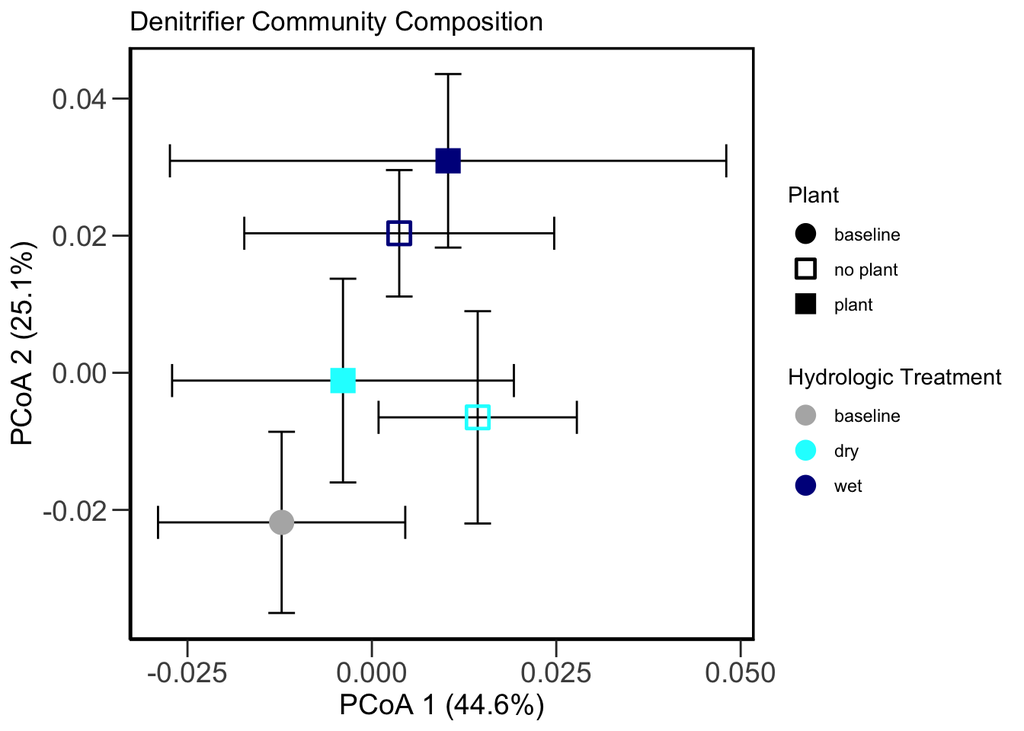

```r
pcoa_denit.groups <- paste(denitRA_design$Treat, denitRA_design$Plant, sep = "_")
pcoa_denit.points <- data.frame(pcoa_denit$points, group = pcoa_denit.groups)

# Calculate Centroids (mean and SE)
pcoa_denit.L.centroids <- reshape2::melt(pcoa_denit.points, id="group", measure.vars = c("X1", "X2"))
pcoa_denit.centroids <- acast(pcoa_denit.L.centroids, variable ~ group, mean)
pcoa_denit.centroids.se <- acast(pcoa_denit.L.centroids, variable ~ group, se)
pcoa_denit.centroids.sd <- acast(pcoa_denit.L.centroids, variable ~ group, sd)

# Combine
pcoa_denit.cent.dataframe <- cbind(t(pcoa_denit.centroids), t(pcoa_denit.centroids.se))
colnames(pcoa_denit.cent.dataframe) <- c("V1", "V2", "V1e", "V2e")

trt <- c("baseline","dry","dry","wet","wet") #this should match the treatments from pcoa_denit.cent.dataframe
plant <- c("baseline","no plant","plant","no plant","plant") #this should match the treatments from pcoa_denit.cent.dataframe

pcoa_denit.cent.dataframe.trts <- as.data.frame(pcoa_denit.cent.dataframe)
pcoa_denit.cent.dataframe.trts$trt <- as.factor(trt) # now you add the new columns that you made above to the pcoa.cent.dataframe.trts df
pcoa_denit.cent.dataframe.trts$plant <- as.factor(plant)

#Plot using ggplot2
df1a <- as.data.frame(pcoa_denit.cent.dataframe.trts)
plot1a <- ggplot(df1a, aes(x=V1, y=V2, colour=trt, shape = plant)) + theme_bw()
plot1a + theme(panel.grid.major = element_blank(),
               panel.grid.minor = element_blank(),
               axis.line = element_line(colour = "black")) +
  theme(panel.background = element_blank()) +
  geom_errorbarh(aes(xmax=V1+V1e, xmin=V1-V1e), colour="black") +
  geom_errorbar(aes(ymax=V2+V2e, ymin=V2-V2e), colour="black") +
  geom_point(aes(colour=trt), size=5, stroke = 1.25, show.legend = TRUE) +
  scale_colour_manual(labels = c("baseline","dry","wet"),
                      values = c("gray70", "cyan", "darkblue")) +
  scale_shape_manual(labels = c("baseline","no plant","plant"), values = c(16,22,15)) +
  theme(axis.title = element_text(size=14),
        axis.text = element_text(size=14),
        axis.text.x = element_text(size=14),
        panel.border = element_rect(colour = "black", size = 1.25)) +
  theme(axis.ticks.length = unit(0.3, "cm")) +
        xlab("PCoA 1 (44.6%)") + ylab("PCoA 2 (25.1%)") +
        labs(colour = "Hydrologic Treatment", shape = "Plant") +
    guides(colour = guide_legend(override.aes = list(pch=16, size = 4)),
           shape = guide_legend(override.aes = list(size = 4))) +
    ggtitle("Denitrifier Community Composition")
```

```r
#ggsave("../figures/DNFcomposition1a.jpg", plot=last_plot(), device=NULL, path=NULL, scale=1, width=7, height=5, dpi=300, limitsize=TRUE)
```

Principal Coordinates Analysis (PCoA) denitrification, including hydrologic history and envfit:

```r
# Classical (Metric) Multidimensional Scaling; returns PCoA coordinates
# eig=TRUE returns eigenvalues; k = # of dimensions to calculate
pcoa_denit <- cmdscale(denitBC, k=3, eig=TRUE, add=FALSE)

explainvar1b_denit <- round(pcoa_denit$eig[1] / sum(pcoa_denit$eig), 3) * 100
explainvar2b_denit <- round(pcoa_denit$eig[2] / sum(pcoa_denit$eig), 3) * 100
sum.eigb <- sum(explainvar1b_denit, explainvar2b_denit)

explainvar1b_denit # 44.6
```

```
## [1] 44.6
```

```r
explainvar2b_denit # 25.1
```

```
## [1] 25.1
```

```r
pcoa_denit2.groups <- paste(denitRA_design$Treat, denitRA_design$Plant, denitRA_design$Hist, sep = "_")
pcoa_denit2.points <- data.frame(pcoa_denit$points, group = pcoa_denit2.groups)

# Calculate Centroids (mean and SE)
pcoa_denit2.L.centroids <- reshape2::melt(pcoa_denit2.points, id="group", measure.vars = c("X1", "X2"))
pcoa_denit2.centroids <- acast(pcoa_denit2.L.centroids, variable ~ group, mean)
pcoa_denit2.centroids.se <- acast(pcoa_denit2.L.centroids, variable ~ group, se)
pcoa_denit2.centroids.sd <- acast(pcoa_denit2.L.centroids, variable ~ group, sd)

# Combine
pcoa_denit2.cent.dataframe <- cbind(t(pcoa_denit2.centroids), t(pcoa_denit2.centroids.se))
colnames(pcoa_denit2.cent.dataframe) <- c("V1", "V2", "V1e", "V2e")

trt <- c("baseline", "baseline", "dry","dry", "dry","dry","wet","wet", "wet","wet")
plant <- c("baseline", "baseline", "no plant","no plant","plant", "plant", "no plant","no plant","plant", "plant")
history <- c("D", "W", "D", "W", "D", "W", "D", "W", "D", "W")
hydro_combined <- c(paste(trt, history, sep = "_"))

pcoa_denit2.cent.dataframe.trts <- as.data.frame(pcoa_denit2.cent.dataframe)
pcoa_denit2.cent.dataframe.trts$trt <- as.factor(trt) # now you add the new columns that you made above to the pcoa.cent.dataframe.trts df
pcoa_denit2.cent.dataframe.trts$plant <- as.factor(plant)
pcoa_denit2.cent.dataframe.trts$history <- as.factor(history)
pcoa_denit2.cent.dataframe.trts$hydro_combined <- as.factor(hydro_combined)

#Run envfit to see which [GHG]s (start or finish) are explained by ordination:
#fit_denit2 <- envfit(pcoa_denit$points, GHG_metaG$mg.N2O.N.m.2, permutations = 1000) # Could use if I wanted only [N2O]
fit_denit2 <- envfit(pcoa_denit$points, GHG_metaG, permutations = 1000)
fit_denit2
```

```
##
## ***VECTORS
##
##                  Dim1     Dim2     r2  Pr(>r)
## ug.ch4c.m2    0.45821 -0.88885 0.1748 0.14685
## mg.CH4.N.m.2  0.45821 -0.88885 0.1748 0.14685
## g.CH4.N.m.2   0.45821 -0.88885 0.1748 0.14685
## ug.co2c.m2   -0.01292 -0.99992 0.2455 0.05495 .
## mg.CO2.N.m.2 -0.01292 -0.99992 0.2455 0.05495 .
## g.CO2.N.m.2  -0.01292 -0.99992 0.2455 0.05495 .
## ug.n2on.m2   -0.20917 -0.97788 0.1330 0.22178
## mg.N2O.N.m.2 -0.20911 -0.97789 0.1330 0.22178
## g.N2O.N.m.2  -0.21030 -0.97764 0.1147 0.27173
## ---
## Signif. codes:  0 '***' 0.001 '**' 0.01 '*' 0.05 '.' 0.1 ' ' 1
## Permutation: free
## Number of permutations: 1000
```

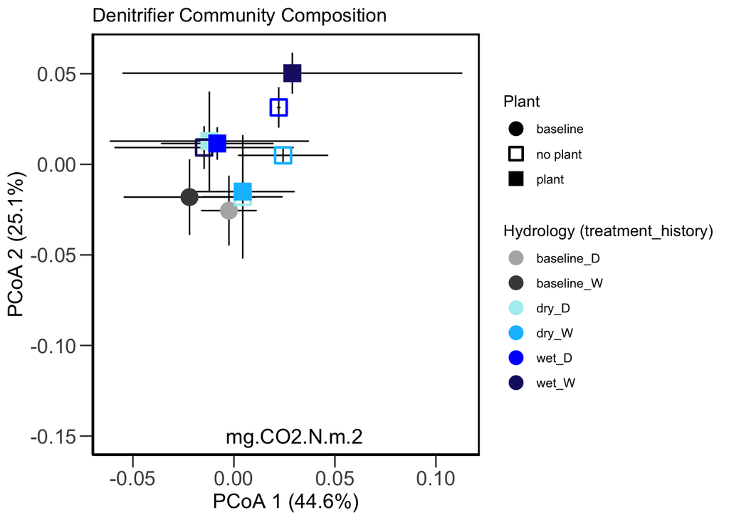

```r
A_denit2 <-as.list(fit_denit2$vectors)
vec_denit2 <- as.data.frame(fit_denit2$vectors$arrows*sqrt(fit_denit2$vectors$r)*0.35) #What is this calculation?
p_denit2 <- as.data.frame(A_denit2$pvals)
vec_denit2 <- cbind(vec_denit2, p_denit2)
vec_denit2 <- subset(vec_denit2, A_denit2$pvals<=0.05)
vec_denit2 <- vec_denit2[2, ] #Only use mg of gas, instead of ug or g

#Plot using ggplot2
df1b <- as.data.frame(pcoa_denit2.cent.dataframe.trts)
plot1b <- ggplot(df1b, aes(x=V1, y=V2, colour=hydro_combined, shape = plant)) + theme_bw()
plot1b + theme(panel.grid.major = element_blank(),
               panel.grid.minor = element_blank(),
               axis.line = element_line(colour = "black")) +
  theme(panel.background = element_blank()) +
  geom_errorbarh(aes(xmax=V1+V1e, xmin=V1-V1e), colour="black") +
  geom_errorbar(aes(ymax=V2+V2e, ymin=V2-V2e), colour="black") +
  geom_point(aes(colour=hydro_combined, shape=plant), size=5, stroke = 1.25, show.legend = TRUE) +
  geom_segment(data=vec_denit2, aes(x=0,xend=Dim1,y=0,yend=Dim2), size=1,
      arrow = arrow(length = unit(0.2, "cm")),colour="black",inherit.aes=F)+
  geom_text(data=vec_denit2, aes(x=0.03,y=-0.15,label="mg.CO2.N.m.2"), size=5, inherit.aes=F)+
  scale_colour_manual(labels = c("baseline_D", "baseline_W", "dry_D", "dry_W", "wet_D", "wet_W"),
                      values = c("gray70", "grey28", "paleturquoise", "deepskyblue", "blue", "midnightblue")) +
  scale_shape_manual(labels = c("baseline","no plant","plant"), values = c(16,22,15)) +
  theme(axis.title = element_text(size=14),
        axis.text = element_text(size=14),
        axis.text.x = element_text(size=14),
        panel.border = element_rect(colour = "black", size = 1.25)) +
  theme(axis.ticks.length = unit(0.3, "cm")) +
        xlab("PCoA 1 (44.6%)") + ylab("PCoA 2 (25.1%)") +
        labs(colour = "Hydrology (treatment_history)", shape = "Plant") +
    guides(colour = guide_legend(override.aes = list(pch=16, size = 4)),
           shape = guide_legend(override.aes = list(size = 4))) +
    ggtitle("Denitrifier Community Composition")
```

```r
#ggsave("../figures/DNFcomposition1b.jpg", plot=last_plot(), device=NULL, path=NULL, scale=1, width=7, height=5, dpi=300, limitsize=TRUE)
```

Principal Coordinates Analysis (PCoA) methanogenesis:

```r
# Classical (Metric) Multidimensional Scaling; returns PCoA coordinates
# eig=TRUE returns eigenvalues; k = # of dimensions to calculate
pcoa_meth <- cmdscale(methBC, k=3, eig=TRUE, add=FALSE)

explainvar1b_meth <- round(pcoa_meth$eig[1] / sum(pcoa_meth$eig), 3) * 100
explainvar2b_meth <- round(pcoa_meth$eig[2] / sum(pcoa_meth$eig), 3) * 100
sum.eigb <- sum(explainvar1b_meth, explainvar2b_meth)

explainvar1b_meth # 41.3
```

```
## [1] 41.3
```

```r
explainvar2b_meth # 27.8
```

```
## [1] 27.8
```

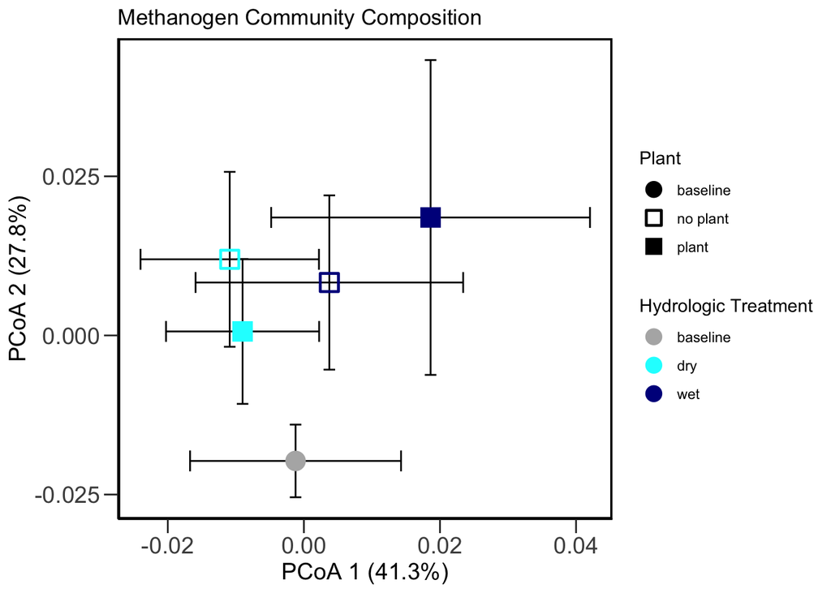

```r
pcoa_meth.groups <- paste(methRA_design$Treat, methRA_design$Plant, sep = "_")
pcoa_meth.points <- data.frame(pcoa_meth$points, group = pcoa_meth.groups)

# Calculate Centroids (mean and SE)
pcoa_meth.L.centroids <- reshape2::melt(pcoa_meth.points, id="group", measure.vars = c("X1", "X2"))
pcoa_meth.centroids <- acast(pcoa_meth.L.centroids, variable ~ group, mean)
pcoa_meth.centroids.se <- acast(pcoa_meth.L.centroids, variable ~ group, se)
pcoa_meth.centroids.sd <- acast(pcoa_meth.L.centroids, variable ~ group, sd)

# Combine
pcoa_meth.cent.dataframe <- cbind(t(pcoa_meth.centroids), t(pcoa_meth.centroids.se))
colnames(pcoa_meth.cent.dataframe) <- c("V1", "V2", "V1e", "V2e")

trt <- c("baseline","dry","dry","wet","wet")
plant <- c("baseline","no plant","plant","no plant","plant")

pcoa_meth.cent.dataframe.trts <- as.data.frame(pcoa_meth.cent.dataframe)
pcoa_meth.cent.dataframe.trts$trt <- as.factor(trt) # now you add the new columns that you made above to the pcoa.cent.dataframe.trts df
pcoa_meth.cent.dataframe.trts$plant <- as.factor(plant)

#Plot using ggplot2
df2a <- as.data.frame(pcoa_meth.cent.dataframe.trts)
plot2a <- ggplot(df2a, aes(x=V1, y=V2, colour=trt, shape = plant)) + theme_bw()
plot2a + theme(panel.grid.major = element_blank(),
               panel.grid.minor = element_blank(),
               axis.line = element_line(colour = "black")) +
  theme(panel.background = element_blank()) +
  geom_errorbarh(aes(xmax=V1+V1e, xmin=V1-V1e), colour="black") +
  geom_errorbar(aes(ymax=V2+V2e, ymin=V2-V2e), colour="black") +
  geom_point(aes(colour=trt), size=5, stroke = 1.25, show.legend = TRUE) +
  scale_colour_manual(labels = c("baseline","dry","wet"),
                      values = c("gray70", "cyan", "darkblue")) +
  scale_shape_manual(labels = c("baseline","no plant","plant"), values = c(16,22,15)) +
  theme(axis.title = element_text(size=14),
        axis.text = element_text(size=14),
        axis.text.x = element_text(size=14),
        panel.border = element_rect(colour = "black", size = 1.25)) +
  theme(axis.ticks.length = unit(0.3, "cm")) +
        xlab("PCoA 1 (41.3%)") + ylab("PCoA 2 (27.8%)") +
        labs(colour = "Hydrologic Treatment", shape = "Plant") +
    guides(colour = guide_legend(override.aes = list(pch=16, size = 4)),
           shape = guide_legend(override.aes = list(size = 4))) +
    ggtitle("Methanogen Community Composition")
```

```r
#ggsave("../figures/METHcomposition2a.jpg", plot=last_plot(), device=NULL, path=NULL, scale=1, width=7, height=5, dpi=300, limitsize=TRUE)
```

Principal Coordinates Analysis (PCoA) methanogenis, including hydrologic history and envfit:

```r
# Classical (Metric) Multidimensional Scaling; returns PCoA coordinates
# eig=TRUE returns eigenvalues; k = # of dimensions to calculate
pcoa_meth <- cmdscale(methBC, k=3, eig=TRUE, add=FALSE)

explainvar1b_meth <- round(pcoa_meth$eig[1] / sum(pcoa_meth$eig), 3) * 100
explainvar2b_meth <- round(pcoa_meth$eig[2] / sum(pcoa_meth$eig), 3) * 100
sum.eigb <- sum(explainvar1b_meth, explainvar2b_meth)

explainvar1b_meth # 41.3
```

```
## [1] 41.3
```

```r
explainvar2b_meth # 27.8
```

```
## [1] 27.8
```

```r
pcoa_meth2.groups <- paste(methRA_design$Treat, methRA_design$Plant, methRA_design$Hist, sep = "_")
pcoa_meth2.points <- data.frame(pcoa_meth$points, group = pcoa_meth2.groups)

# Calculate Centroids (mean and SE)
pcoa_meth2.L.centroids <- reshape2::melt(pcoa_meth2.points, id="group", measure.vars = c("X1", "X2"))
pcoa_meth2.centroids <- acast(pcoa_meth2.L.centroids, variable ~ group, mean)
pcoa_meth2.centroids.se <- acast(pcoa_meth2.L.centroids, variable ~ group, se)
pcoa_meth2.centroids.sd <- acast(pcoa_meth2.L.centroids, variable ~ group, sd)

# Combine
pcoa_meth2.cent.dataframe <- cbind(t(pcoa_meth2.centroids), t(pcoa_meth2.centroids.se))
colnames(pcoa_meth2.cent.dataframe) <- c("V1", "V2", "V1e", "V2e")

#trt <- c("baseline", "baseline", "dry","dry", "dry","dry","wet","wet", "wet","wet")
#plant <- c("baseline", "baseline", "no plant","no plant","plant", "plant", "no plant","no plant","plant", "plant")
#history <- c("D", "W", "D", "W", "D", "W", "D", "W", "D", "W")
#hydro_combined <- c(paste(trt, history, sep = "_"))

pcoa_meth2.cent.dataframe.trts <- as.data.frame(pcoa_meth2.cent.dataframe)
pcoa_meth2.cent.dataframe.trts$trt <- as.factor(trt) # now you add the new columns that you made above to the pcoa.cent.dataframe.trts df
pcoa_meth2.cent.dataframe.trts$plant <- as.factor(plant)
pcoa_meth2.cent.dataframe.trts$history <- as.factor(history)
pcoa_meth2.cent.dataframe.trts$hydro_combined <- as.factor(hydro_combined)

#Run envfit to see which [GHG]s (start or finish) are explained by ordination:
fit_meth2 <- envfit(pcoa_meth$points, GHG_metaG, permutations = 1000)
fit_meth2 # No significant P-values, so not proceeding with envfit plotting for now
```

```
##
## ***VECTORS
##
##                  Dim1     Dim2     r2  Pr(>r)
## ug.ch4c.m2   -0.93526  0.35396 0.2045 0.08392 .
## mg.CH4.N.m.2 -0.93526  0.35396 0.2045 0.08392 .
## g.CH4.N.m.2  -0.93526  0.35396 0.2045 0.08392 .
## ug.co2c.m2   -0.74087  0.67165 0.0322 0.71928
## mg.CO2.N.m.2 -0.74087  0.67165 0.0322 0.71928
## g.CO2.N.m.2  -0.74087  0.67165 0.0322 0.71928
## ug.n2on.m2    0.92536 -0.37909 0.0268 0.80719
## mg.N2O.N.m.2  0.92534 -0.37915 0.0268 0.80719
## g.N2O.N.m.2   0.96129 -0.27553 0.0265 0.81818
## ---
## Signif. codes:  0 '***' 0.001 '**' 0.01 '*' 0.05 '.' 0.1 ' ' 1
## Permutation: free
## Number of permutations: 1000
```

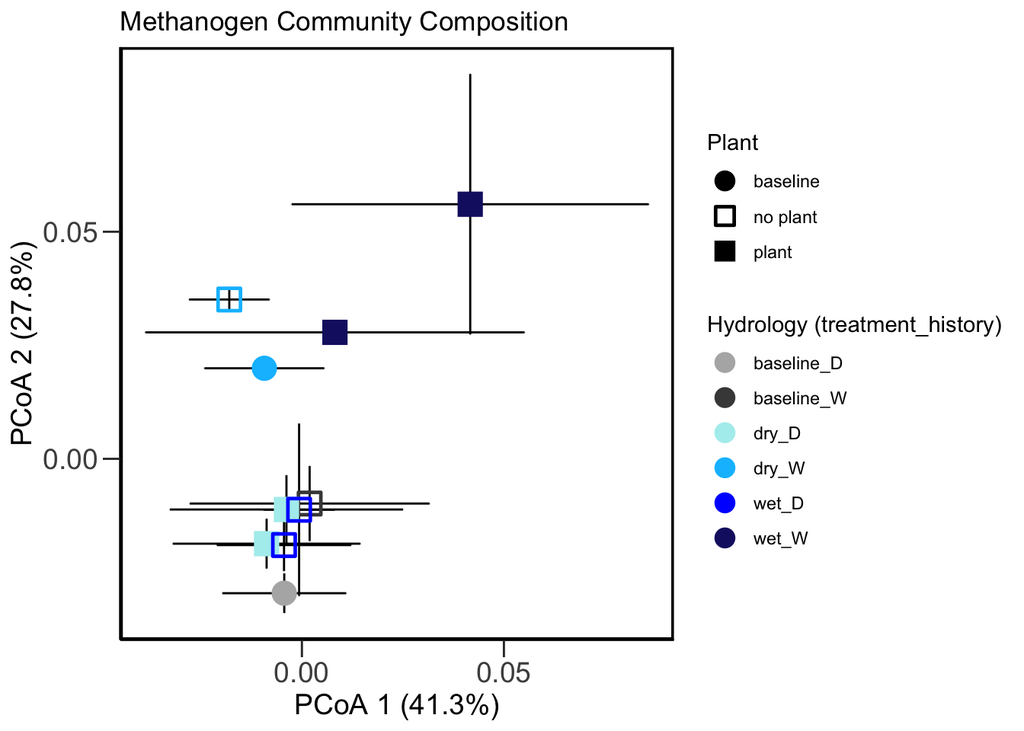

```r
#A_meth2 <-as.list(fit_meth2$vectors)
#vec_meth2 <- as.data.frame(fit_meth2$vectors$arrows*sqrt(fit_meth2$vectors$r)*0.35) #What is this calculation?
#p_meth2 <- as.data.frame(A_meth2$pvals)
#vec_meth2 <- cbind(vec_meth2, p_meth2)
#vec_meth2 <- subset(vec_meth2, A_meth2$pvals<=0.05)
#vec_meth2 <- vec_meth2[2, ] #Only use mg of gas, instead of ug or g

#Plot using ggplot2
df2b <- as.data.frame(pcoa_meth2.cent.dataframe.trts)
plot2b <- ggplot(df2b, aes(x=V1, y=V2, colour=hydro_combined, shape = plant)) + theme_bw()
plot2b + theme(panel.grid.major = element_blank(),
               panel.grid.minor = element_blank(),
               axis.line = element_line(colour = "black")) +
  theme(panel.background = element_blank()) +
  geom_errorbarh(aes(xmax=V1+V1e, xmin=V1-V1e), colour="black") +
  geom_errorbar(aes(ymax=V2+V2e, ymin=V2-V2e), colour="black") +
  geom_point(aes(colour=hydro_combined, shape=plant), size=5, stroke = 1.25, show.legend = TRUE) +
  #geom_segment(data=vec_meth2, aes(x=0,xend=Dim1,y=0,yend=Dim2), size=1,
      #arrow = arrow(length = unit(0.2, "cm")),colour="black",inherit.aes=F)+
  #geom_text(data=vec_meth2, aes(x=0.03,y=-0.15,label="mg.CO2.N.m.2"), size=5, inherit.aes=F)+
  scale_colour_manual(labels = c("baseline_D", "baseline_W", "dry_D", "dry_W", "wet_D", "wet_W"),
                      values = c("gray70", "grey28", "paleturquoise", "deepskyblue", "blue", "midnightblue")) +
  scale_shape_manual(labels = c("baseline","no plant","plant"), values = c(16,22,15)) +
  theme(axis.title = element_text(size=14),
        axis.text = element_text(size=14),
        axis.text.x = element_text(size=14),
        panel.border = element_rect(colour = "black", size = 1.25)) +
  theme(axis.ticks.length = unit(0.3, "cm")) +
        xlab("PCoA 1 (41.3%)") + ylab("PCoA 2 (27.8%)") +
        labs(colour = "Hydrology (treatment_history)", shape = "Plant") +
    guides(colour = guide_legend(override.aes = list(pch=16, size = 4)),
           shape = guide_legend(override.aes = list(size = 4))) +
    ggtitle("Methanogen Community Composition")
```

```r
#ggsave("../figures/METHcomposition2b.jpg", plot=last_plot(), device=NULL, path=NULL, scale=1, width=7, height=5, dpi=300, limitsize=TRUE)
```

Principal Coordinates Analysis (PCoA) central carbohydrate metabolism:

```r
# Classical (Metric) Multidimensional Scaling; returns PCoA coordinates
# eig=TRUE returns eigenvalues; k = # of dimensions to calculate
pcoa_carb_metab <- cmdscale(carb_metabBC, k=3, eig=TRUE, add=FALSE)

explainvar1b_carb_metab <- round(pcoa_carb_metab$eig[1] / sum(pcoa_carb_metab$eig), 3) * 100
explainvar2b_carb_metab <- round(pcoa_carb_metab$eig[2] / sum(pcoa_carb_metab$eig), 3) * 100
sum.eigb <- sum(explainvar1b_carb_metab, explainvar2b_carb_metab)

explainvar1b_carb_metab # 33.7
```

```
## [1] 33.7
```

```r
explainvar2b_carb_metab # 15.9
```

```
## [1] 15.9
```

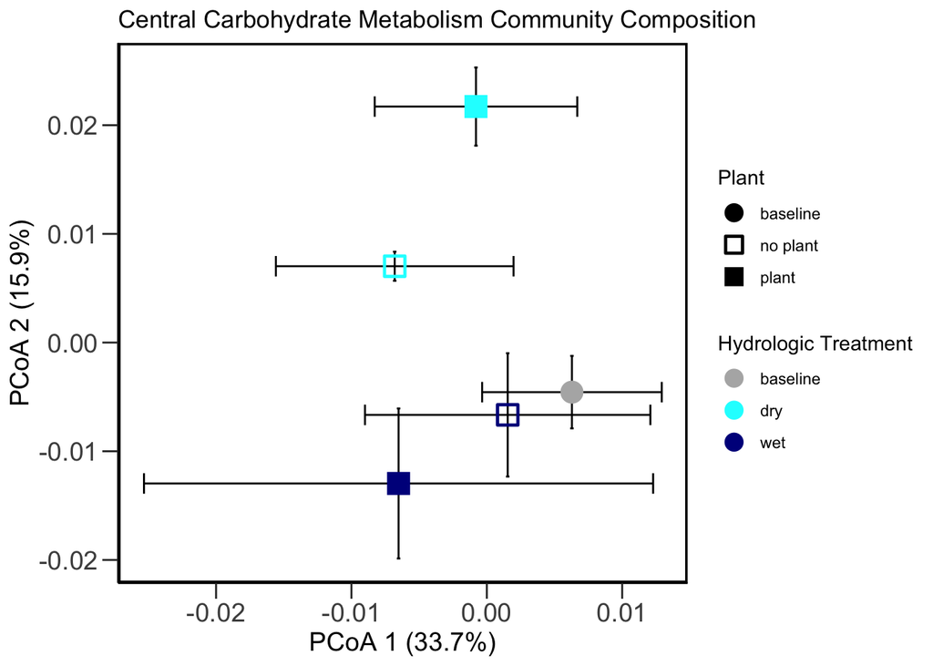

```r
pcoa_carb_metab.groups <- paste(carb_metabRA_design$Treat, carb_metabRA_design$Plant, sep = "_")
pcoa_carb_metab.points <- data.frame(pcoa_carb_metab$points, group = pcoa_carb_metab.groups)

# Calculate Centroids (mean and SE)
pcoa_carb_metab.L.centroids <- reshape2::melt(pcoa_carb_metab.points, id="group", measure.vars = c("X1", "X2"))
pcoa_carb_metab.centroids <- acast(pcoa_carb_metab.L.centroids, variable ~ group, mean)
pcoa_carb_metab.centroids.se <- acast(pcoa_carb_metab.L.centroids, variable ~ group, se)
pcoa_carb_metab.centroids.sd <- acast(pcoa_carb_metab.L.centroids, variable ~ group, sd)

# Combine
pcoa_carb_metab.cent.dataframe <- cbind(t(pcoa_carb_metab.centroids), t(pcoa_carb_metab.centroids.se))
colnames(pcoa_carb_metab.cent.dataframe) <- c("V1", "V2", "V1e", "V2e")

trt <- c("baseline","dry","dry","wet","wet")
plant <- c("baseline","no plant","plant","no plant","plant")

pcoa_carb_metab.cent.dataframe.trts <- as.data.frame(pcoa_carb_metab.cent.dataframe)
pcoa_carb_metab.cent.dataframe.trts$trt <- as.factor(trt) # now you add the new columns that you made above to the pcoa.cent.dataframe.trts df
pcoa_carb_metab.cent.dataframe.trts$plant <- as.factor(plant)

#Plot using ggplot2
df3a <- as.data.frame(pcoa_carb_metab.cent.dataframe.trts)
plot3a <- ggplot(df3a, aes(x=V1, y=V2, colour=trt, shape = plant)) + theme_bw()
plot3a + theme(panel.grid.major = element_blank(),
               panel.grid.minor = element_blank(),
               axis.line = element_line(colour = "black")) +
  theme(panel.background = element_blank()) +
  geom_errorbarh(aes(xmax=V1+V1e, xmin=V1-V1e), colour="black") +
  geom_errorbar(aes(ymax=V2+V2e, ymin=V2-V2e), colour="black") +
  geom_point(aes(colour=trt), size=5, stroke = 1.25, show.legend = TRUE) +
  scale_colour_manual(labels = c("baseline","dry","wet"),
                      values = c("gray70", "cyan", "darkblue")) +
  scale_shape_manual(labels = c("baseline","no plant","plant"), values = c(16,22,15)) +
  theme(axis.title = element_text(size=14),
        axis.text = element_text(size=14),
        axis.text.x = element_text(size=14),
        panel.border = element_rect(colour = "black", size = 1.25)) +
  theme(axis.ticks.length = unit(0.3, "cm")) +
        xlab("PCoA 1 (33.7%)") + ylab("PCoA 2 (15.9%)") +
        labs(colour = "Hydrologic Treatment", shape = "Plant") +
    guides(colour = guide_legend(override.aes = list(pch=16, size = 4)),
           shape = guide_legend(override.aes = list(size = 4))) +
    ggtitle("Central Carbohydrate Metabolism Community Composition")
```

```r
#ggsave("../figures/CARBcomposition3a.jpg", plot=last_plot(), device=NULL, path=NULL, scale=1, width=7, height=5, dpi=300, limitsize=TRUE)
```

Principal Coordinates Analysis (PCoA) central carbohydrate metabolism with hydrologic history and envfit:

```r
# Classical (Metric) Multidimensional Scaling; returns PCoA coordinates
# eig=TRUE returns eigenvalues; k = # of dimensions to calculate
pcoa_carb_metab <- cmdscale(carb_metabBC, k=3, eig=TRUE, add=FALSE)

explainvar1b_carb_metab <- round(pcoa_carb_metab$eig[1] / sum(pcoa_carb_metab$eig), 3) * 100
explainvar2b_carb_metab <- round(pcoa_carb_metab$eig[2] / sum(pcoa_carb_metab$eig), 3) * 100
sum.eigb <- sum(explainvar1b_carb_metab, explainvar2b_carb_metab)

explainvar1b_carb_metab # 33.7
```

```
## [1] 33.7
```

```r
explainvar2b_carb_metab # 15.9
```

```
## [1] 15.9
```

```r
pcoa_carb_metab2.groups <- paste(carb_metabRA_design$Treat, carb_metabRA_design$Plant, carb_metabRA_design$Hist, sep = "_")
pcoa_carb_metab2.points <- data.frame(pcoa_carb_metab$points, group = pcoa_carb_metab2.groups)

# Calculate Centroids (mean and SE)
pcoa_carb_metab2.L.centroids <- reshape2::melt(pcoa_carb_metab2.points, id="group", measure.vars = c("X1", "X2"))
pcoa_carb_metab2.centroids <- acast(pcoa_carb_metab2.L.centroids, variable ~ group, mean)
pcoa_carb_metab2.centroids.se <- acast(pcoa_carb_metab2.L.centroids, variable ~ group, se)
pcoa_carb_metab2.centroids.sd <- acast(pcoa_carb_metab2.L.centroids, variable ~ group, sd)

# Combine
pcoa_carb_metab2.cent.dataframe <- cbind(t(pcoa_carb_metab2.centroids), t(pcoa_carb_metab2.centroids.se))
colnames(pcoa_carb_metab2.cent.dataframe) <- c("V1", "V2", "V1e", "V2e")

#trt <- c("baseline", "baseline", "dry","dry", "dry","dry","wet","wet", "wet","wet")
#plant <- c("baseline", "baseline", "no plant","no plant","plant", "plant", "no plant","no plant","plant", "plant")
#history <- c("D", "W", "D", "W", "D", "W", "D", "W", "D", "W")
#hydro_combined <- c(paste(trt, history, sep = "_"))

pcoa_carb_metab2.cent.dataframe.trts <- as.data.frame(pcoa_carb_metab2.cent.dataframe)
pcoa_carb_metab2.cent.dataframe.trts$trt <- as.factor(trt) # now you add the new columns that you made above to the pcoa.cent.dataframe.trts df
pcoa_carb_metab2.cent.dataframe.trts$plant <- as.factor(plant)
pcoa_carb_metab2.cent.dataframe.trts$history <- as.factor(history)
pcoa_carb_metab2.cent.dataframe.trts$hydro_combined <- as.factor(hydro_combined)

#Run envfit to see which [GHG]s (start or finish) are explained by ordination:
fit_carb_metab2 <- envfit(pcoa_carb_metab$points, GHG_metaG, permutations = 1000)
fit_carb_metab2 # No significant P-values, so not proceeding with envfit plotting for now
```

```
##
## ***VECTORS
##
##                  Dim1     Dim2     r2  Pr(>r)
## ug.ch4c.m2   -0.99714 -0.07555 0.0330 0.68731
## mg.CH4.N.m.2 -0.99714 -0.07555 0.0330 0.68731
## g.CH4.N.m.2  -0.99714 -0.07555 0.0330 0.68731
## ug.co2c.m2   -0.50444  0.86345 0.2330 0.06194 .
## mg.CO2.N.m.2 -0.50444  0.86345 0.2330 0.06194 .
## g.CO2.N.m.2  -0.50444  0.86345 0.2330 0.06194 .
## ug.n2on.m2   -0.11929  0.99286 0.0023 0.98402
## mg.N2O.N.m.2 -0.11911  0.99288 0.0023 0.98402
## g.N2O.N.m.2  -0.09593  0.99539 0.0038 0.98202
## ---
## Signif. codes:  0 '***' 0.001 '**' 0.01 '*' 0.05 '.' 0.1 ' ' 1
## Permutation: free
## Number of permutations: 1000
```

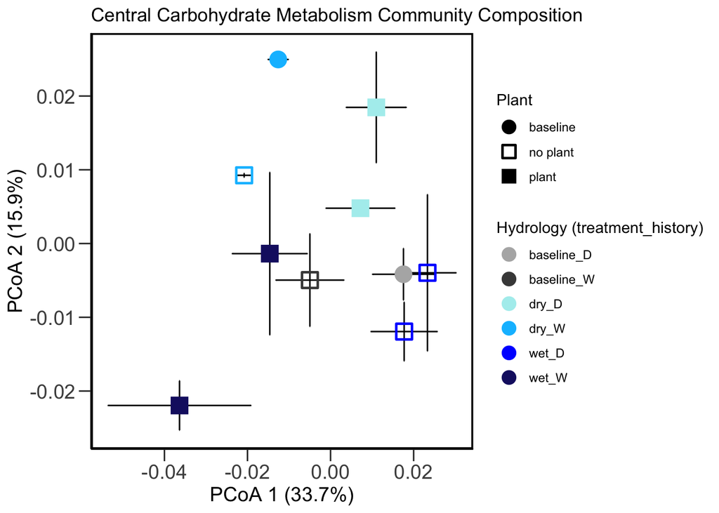

```r
#A_carb_metab2 <-as.list(fit_carb_metab2$vectors)
#vec_carb_metab2 <- as.data.frame(fit_carb_metab2$vectors$arrows*sqrt(fit_carb_metab2$vectors$r)*0.35) #What is this calculation?
#p_carb_metab2 <- as.data.frame(A_carb_metab2$pvals)
#vec_carb_metab2 <- cbind(vec_carb_metab2, p_carb_metab2)
#vec_carb_metab2 <- subset(vec_carb_metab2, A_carb_metab2$pvals<=0.05)
#vec_carb_metab2 <- vec_carb_metab2[2, ] #Only use mg of gas, instead of ug or g

#Plot using ggplot2
df3b <- as.data.frame(pcoa_carb_metab2.cent.dataframe.trts)
plot3b <- ggplot(df3b, aes(x=V1, y=V2, colour=hydro_combined, shape = plant)) + theme_bw()
plot3b + theme(panel.grid.major = element_blank(),
               panel.grid.minor = element_blank(),
               axis.line = element_line(colour = "black")) +
  theme(panel.background = element_blank()) +
  geom_errorbarh(aes(xmax=V1+V1e, xmin=V1-V1e), colour="black") +
  geom_errorbar(aes(ymax=V2+V2e, ymin=V2-V2e), colour="black") +
  geom_point(aes(colour=hydro_combined, shape=plant), size=5, stroke = 1.25, show.legend = TRUE) +
  #geom_segment(data=vec_carb_metab2, aes(x=0,xend=Dim1,y=0,yend=Dim2), size=1,
      #arrow = arrow(length = unit(0.2, "cm")),colour="black",inherit.aes=F)+
  #geom_text(data=vec_carb_metab2, aes(x=0.03,y=-0.15,label="mg.CO2.N.m.2"), size=5, inherit.aes=F)+
  scale_colour_manual(labels = c("baseline_D", "baseline_W", "dry_D", "dry_W", "wet_D", "wet_W"),
                      values = c("gray70", "grey28", "paleturquoise", "deepskyblue", "blue", "midnightblue")) +
  scale_shape_manual(labels = c("baseline","no plant","plant"), values = c(16,22,15)) +
  theme(axis.title = element_text(size=14),
        axis.text = element_text(size=14),
        axis.text.x = element_text(size=14),
        panel.border = element_rect(colour = "black", size = 1.25)) +
  theme(axis.ticks.length = unit(0.3, "cm")) +
        xlab("PCoA 1 (33.7%)") + ylab("PCoA 2 (15.9%)") +
        labs(colour = "Hydrology (treatment_history)", shape = "Plant") +
    guides(colour = guide_legend(override.aes = list(pch=16, size = 4)),
           shape = guide_legend(override.aes = list(size = 4))) +
    ggtitle("Central Carbohydrate Metabolism Community Composition")
```

```r
#ggsave("../figures/CARBcomposition3b.jpg", plot=last_plot(), device=NULL, path=NULL, scale=1, width=7, height=5, dpi=300, limitsize=TRUE)
```

Principal Coordinates Analysis (PCoA) cytochrome C oxidase:

```r
# Classical (Metric) Multidimensional Scaling; returns PCoA coordinates
# eig=TRUE returns eigenvalues; k = # of dimensions to calculate
pcoa_cytoCox <- cmdscale(cytoCoxBC, k=3, eig=TRUE, add=FALSE)

explainvar1b_cytoCox <- round(pcoa_cytoCox$eig[1] / sum(pcoa_cytoCox$eig), 3) * 100
explainvar2b_cytoCox <- round(pcoa_cytoCox$eig[2] / sum(pcoa_cytoCox$eig), 3) * 100
sum.eigb <- sum(explainvar1b_cytoCox, explainvar2b_cytoCox)

explainvar1b_cytoCox # 50.7
```

```
## [1] 50.7
```

```r
explainvar2b_cytoCox # 35.6
```

```
## [1] 35.6
```

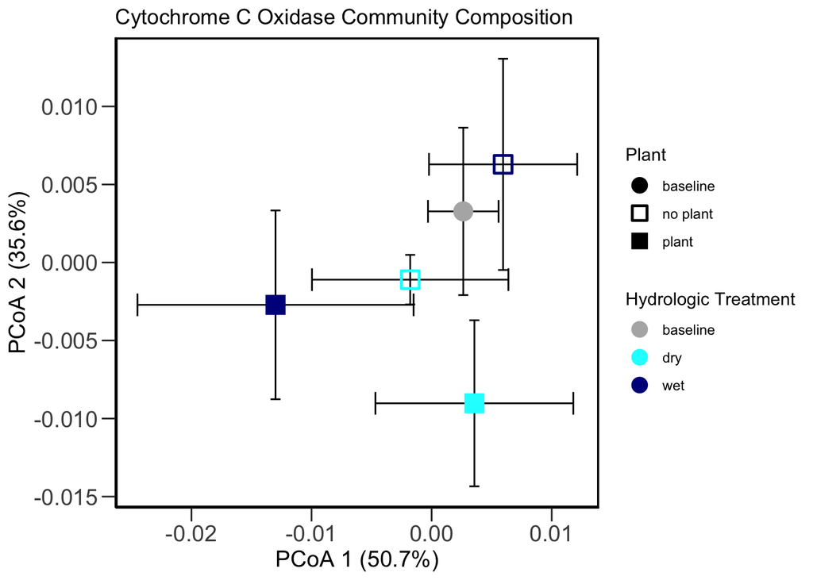

```r
pcoa_cytoCox.groups <- paste(cytoCoxRA_design$Treat, cytoCoxRA_design$Plant, sep = "_")
pcoa_cytoCox.points <- data.frame(pcoa_cytoCox$points, group = pcoa_cytoCox.groups)

# Calculate Centroids (mean and SE)
pcoa_cytoCox.L.centroids <- reshape2::melt(pcoa_cytoCox.points, id="group", measure.vars = c("X1", "X2"))
pcoa_cytoCox.centroids <- acast(pcoa_cytoCox.L.centroids, variable ~ group, mean)
pcoa_cytoCox.centroids.se <- acast(pcoa_cytoCox.L.centroids, variable ~ group, se)
pcoa_cytoCox.centroids.sd <- acast(pcoa_cytoCox.L.centroids, variable ~ group, sd)

# Combine
pcoa_cytoCox.cent.dataframe <- cbind(t(pcoa_cytoCox.centroids), t(pcoa_cytoCox.centroids.se))
colnames(pcoa_cytoCox.cent.dataframe) <- c("V1", "V2", "V1e", "V2e")

trt <- c("baseline","dry","dry","wet","wet")
plant <- c("baseline","no plant","plant","no plant","plant")

pcoa_cytoCox.cent.dataframe.trts <- as.data.frame(pcoa_cytoCox.cent.dataframe)
pcoa_cytoCox.cent.dataframe.trts$trt <- as.factor(trt) # now you add the new columns that you made above to the pcoa.cent.dataframe.trts df
pcoa_cytoCox.cent.dataframe.trts$plant <- as.factor(plant)

#Plot using ggplot2
df4a <- as.data.frame(pcoa_cytoCox.cent.dataframe.trts)
plot4a <- ggplot(df4a, aes(x=V1, y=V2, colour=trt, shape = plant)) + theme_bw()
plot4a + theme(panel.grid.major = element_blank(),
               panel.grid.minor = element_blank(),
               axis.line = element_line(colour = "black")) +
  theme(panel.background = element_blank()) +
  geom_errorbarh(aes(xmax=V1+V1e, xmin=V1-V1e), colour="black") +
  geom_errorbar(aes(ymax=V2+V2e, ymin=V2-V2e), colour="black") +
  geom_point(aes(colour=trt), size=5, stroke = 1.25, show.legend = TRUE) +
  scale_colour_manual(labels = c("baseline","dry","wet"),
                      values = c("gray70", "cyan", "darkblue")) +
  scale_shape_manual(labels = c("baseline","no plant","plant"), values = c(16,22,15)) +
  theme(axis.title = element_text(size=14),
        axis.text = element_text(size=14),
        axis.text.x = element_text(size=14),
        panel.border = element_rect(colour = "black", size = 1.25)) +
  theme(axis.ticks.length = unit(0.3, "cm")) +
        xlab("PCoA 1 (50.7%)") + ylab("PCoA 2 (35.6%)") +
        labs(colour = "Hydrologic Treatment", shape = "Plant") +
    guides(colour = guide_legend(override.aes = list(pch=16, size = 4)),
           shape = guide_legend(override.aes = list(size = 4))) +
    ggtitle("Cytochrome C Oxidase Community Composition")
```

```r
#ggsave("../figures/CcOcomposition4a.jpg", plot=last_plot(), device=NULL, path=NULL, scale=1, width=7, height=5, dpi=300, limitsize=TRUE)
```

Principal Coordinates Analysis (PCoA) cytochrome C oxidase, adding History as text labels:

```r
# Classical (Metric) Multidimensional Scaling; returns PCoA coordinates
# eig=TRUE returns eigenvalues; k = # of dimensions to calculate
pcoa_cytoCox2 <- cmdscale(cytoCoxBC, k=3, eig=TRUE, add=FALSE)

explainvar1b_cytoCox2 <- round(pcoa_cytoCox2$eig[1] / sum(pcoa_cytoCox2$eig), 3) * 100
explainvar2b_cytoCox2 <- round(pcoa_cytoCox2$eig[2] / sum(pcoa_cytoCox2$eig), 3) * 100
sum.eigb <- sum(explainvar1b_cytoCox2, explainvar2b_cytoCox2)

explainvar1b_cytoCox2 # 50.7
```

```
## [1] 50.7
```

```r
explainvar2b_cytoCox2 # 35.6
```

```
## [1] 35.6
```

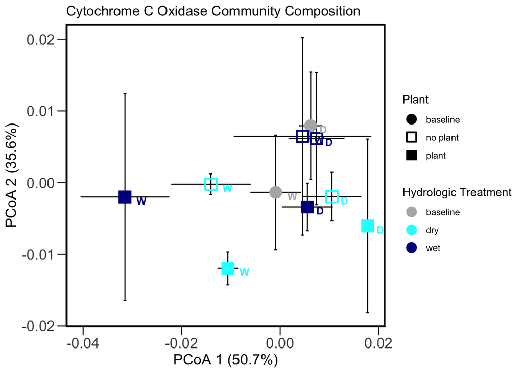

```r
pcoa_cytoCox2.groups <- paste(cytoCoxRA_design$Treat, cytoCoxRA_design$Plant, cytoCoxRA_design$Hist, sep = "_")
pcoa_cytoCox2.points <- data.frame(pcoa_cytoCox2$points, group = pcoa_cytoCox2.groups)

# Calculate Centroids (mean and SE)
pcoa_cytoCox2.L.centroids <- reshape2::melt(pcoa_cytoCox2.points, id="group", measure.vars = c("X1", "X2"))
pcoa_cytoCox2.centroids <- acast(pcoa_cytoCox2.L.centroids, variable ~ group, mean)
pcoa_cytoCox2.centroids.se <- acast(pcoa_cytoCox2.L.centroids, variable ~ group, se)
pcoa_cytoCox2.centroids.sd <- acast(pcoa_cytoCox2.L.centroids, variable ~ group, sd)

# Combine
pcoa_cytoCox2.cent.dataframe <- cbind(t(pcoa_cytoCox2.centroids), t(pcoa_cytoCox2.centroids.se))
colnames(pcoa_cytoCox2.cent.dataframe) <- c("V1", "V2", "V1e", "V2e")

trt <- c("baseline", "baseline", "dry","dry", "dry","dry","wet","wet", "wet","wet")
plant <- c("baseline", "baseline", "no plant","no plant","plant", "plant", "no plant","no plant","plant", "plant")
history <- c("D", "W", "D", "W", "D", "W", "D", "W", "D", "W")

pcoa_cytoCox2.cent.dataframe.trts <- as.data.frame(pcoa_cytoCox2.cent.dataframe)
pcoa_cytoCox2.cent.dataframe.trts$trt <- as.factor(trt) # now you add the new columns that you made above to the pcoa.cent.dataframe.trts df
pcoa_cytoCox2.cent.dataframe.trts$plant <- as.factor(plant)
pcoa_cytoCox2.cent.dataframe.trts$history <- as.factor(history)

#Plot using ggplot2
df4b <- as.data.frame(pcoa_cytoCox2.cent.dataframe.trts)
plot4b <- ggplot(df4b, aes(x=V1, y=V2, colour=trt, shape = plant)) + theme_bw()
plot4b + theme(panel.grid.major = element_blank(),
               panel.grid.minor = element_blank(),
               axis.line = element_line(colour = "black")) +
  theme(panel.background = element_blank()) +
  geom_errorbarh(aes(xmax=V1+V1e, xmin=V1-V1e), colour="black") +
  geom_errorbar(aes(ymax=V2+V2e, ymin=V2-V2e), colour="black") +
  geom_point(aes(colour=trt, shape=plant), size=5, stroke = 1.25, show.legend = TRUE) +
  geom_text(aes(label=history, hjust=-1.2, vjust=1, fontface="bold"), size=3.5, show.legend = FALSE) +
  scale_colour_manual(labels = c("baseline","dry","wet"),
                      values = c("gray70", "cyan", "darkblue")) +
  scale_shape_manual(labels = c("baseline","no plant","plant"), values = c(16,22,15)) +
  theme(axis.title = element_text(size=14),
        axis.text = element_text(size=14),
        axis.text.x = element_text(size=14),
        panel.border = element_rect(colour = "black", size = 1.25)) +
  theme(axis.ticks.length = unit(0.3, "cm")) +
        xlab("PCoA 1 (50.7%)") + ylab("PCoA 2 (35.6%)") +
        labs(colour = "Hydrologic Treatment", shape = "Plant") +
    guides(colour = guide_legend(override.aes = list(pch=16, size = 4)),
           shape = guide_legend(override.aes = list(size = 4)))+
    ggtitle("Cytochrome C Oxidase Community Composition")
```

```r
#ggsave("../figures/CcOcomposition4b.jpg", plot=last_plot(), device=NULL, path=NULL, scale=1, width=7, height=5, dpi=300, limitsize=TRUE)
```

```r
# Classical (Metric) Multidimensional Scaling; returns PCoA coordinates
# eig=TRUE returns eigenvalues; k = # of dimensions to calculate
pcoa_cytoCox3 <- cmdscale(cytoCoxBC, k=3, eig=TRUE, add=FALSE)

explainvar1b_cytoCox3 <- round(pcoa_cytoCox3$eig[1] / sum(pcoa_cytoCox3$eig), 3) * 100
explainvar2b_cytoCox3 <- round(pcoa_cytoCox3$eig[2] / sum(pcoa_cytoCox3$eig), 3) * 100
sum.eigb <- sum(explainvar1b_cytoCox3, explainvar2b_cytoCox3)

explainvar1b_cytoCox3 # 50.7
```

```
## [1] 50.7
```

```r
explainvar2b_cytoCox3 # 35.6
```

```
## [1] 35.6
```

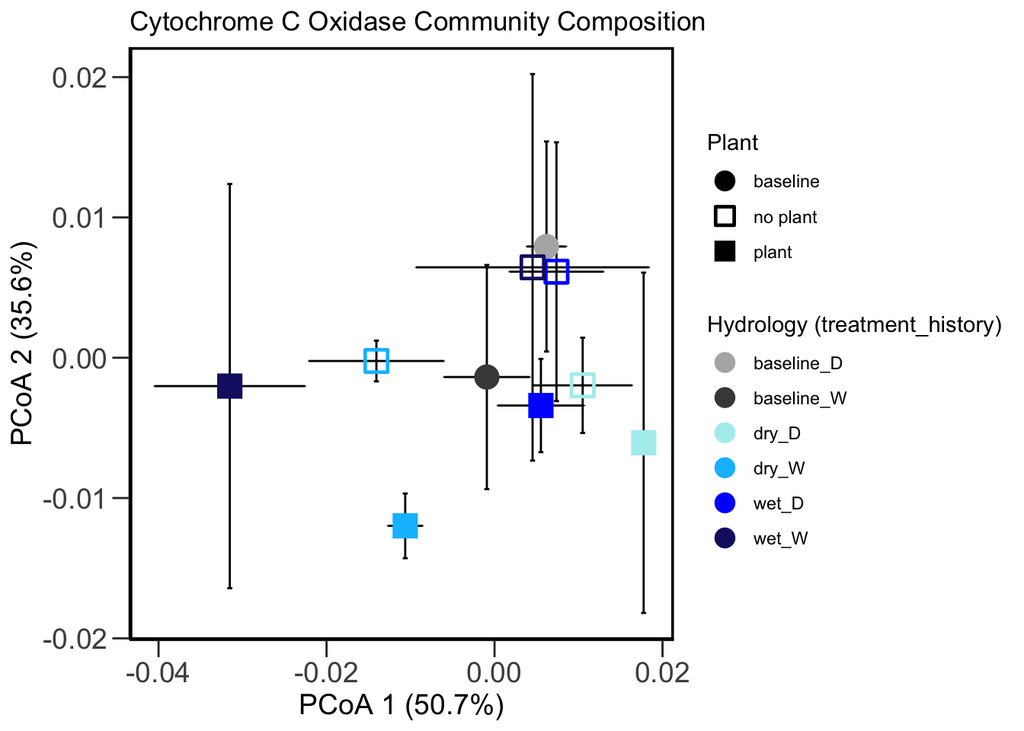

```r
pcoa_cytoCox3.groups <- paste(cytoCoxRA_design$Treat, cytoCoxRA_design$Plant, cytoCoxRA_design$Hist, sep = "_")
pcoa_cytoCox3.points <- data.frame(pcoa_cytoCox3$points, group = pcoa_cytoCox3.groups)

# Calculate Centroids (mean and SE)
pcoa_cytoCox3.L.centroids <- reshape2::melt(pcoa_cytoCox3.points, id="group", measure.vars = c("X1", "X2"))
pcoa_cytoCox3.centroids <- acast(pcoa_cytoCox3.L.centroids, variable ~ group, mean)
pcoa_cytoCox3.centroids.se <- acast(pcoa_cytoCox3.L.centroids, variable ~ group, se)
pcoa_cytoCox3.centroids.sd <- acast(pcoa_cytoCox3.L.centroids, variable ~ group, sd)

# Combine
pcoa_cytoCox3.cent.dataframe <- cbind(t(pcoa_cytoCox3.centroids), t(pcoa_cytoCox3.centroids.se))
colnames(pcoa_cytoCox3.cent.dataframe) <- c("V1", "V2", "V1e", "V2e")

trt <- c("baseline", "baseline", "dry","dry", "dry","dry","wet","wet", "wet","wet")
plant <- c("baseline", "baseline", "no plant","no plant","plant", "plant", "no plant","no plant","plant", "plant")
history <- c("D", "W", "D", "W", "D", "W", "D", "W", "D", "W")
hydro_combined <- c(paste(trt, history, sep = "_"))

pcoa_cytoCox3.cent.dataframe.trts <- as.data.frame(pcoa_cytoCox3.cent.dataframe)
pcoa_cytoCox3.cent.dataframe.trts$trt <- as.factor(trt) # now you add the new columns that you made above to the pcoa.cent.dataframe.trts df
pcoa_cytoCox3.cent.dataframe.trts$plant <- as.factor(plant)
pcoa_cytoCox3.cent.dataframe.trts$history <- as.factor(history)
pcoa_cytoCox3.cent.dataframe.trts$hydro_combined <- as.factor(hydro_combined)

#Plot using ggplot2
df4c <- as.data.frame(pcoa_cytoCox3.cent.dataframe.trts)
plot4c <- ggplot(df4c, aes(x=V1, y=V2, colour=hydro_combined, shape = plant)) + theme_bw()
plot4c + theme(panel.grid.major = element_blank(),
               panel.grid.minor = element_blank(),
               axis.line = element_line(colour = "black")) +
  theme(panel.background = element_blank()) +
  geom_errorbarh(aes(xmax=V1+V1e, xmin=V1-V1e), colour="black") +
  geom_errorbar(aes(ymax=V2+V2e, ymin=V2-V2e), colour="black") +
  geom_point(aes(colour=hydro_combined, shape=plant), size=5, stroke = 1.25, show.legend = TRUE) +
  scale_colour_manual(labels = c("baseline_D", "baseline_W", "dry_D", "dry_W", "wet_D", "wet_W"),
                      values = c("gray70", "grey28", "paleturquoise", "deepskyblue", "blue", "midnightblue")) +
  scale_shape_manual(labels = c("baseline","no plant","plant"), values = c(16,22,15)) +
  theme(axis.title = element_text(size=14),
        axis.text = element_text(size=14),
        axis.text.x = element_text(size=14),
        panel.border = element_rect(colour = "black", size = 1.25)) +
  theme(axis.ticks.length = unit(0.3, "cm")) +
        xlab("PCoA 1 (50.7%)") + ylab("PCoA 2 (35.6%)") +
        labs(colour = "Hydrology (treatment_history)", shape = "Plant") +
    guides(colour = guide_legend(override.aes = list(pch=16, size = 4)),
           shape = guide_legend(override.aes = list(size = 4)))+
    ggtitle("Cytochrome C Oxidase Community Composition")
```

```r
ggsave("../figures/CcOcomposition4c.jpg", plot=last_plot(), device=NULL, path=NULL, scale=1, width=7, height=5, dpi=300, limitsize=TRUE)
```

Now trying to add envit() of start and final [CO2] to plot4c:

```r
# Classical (Metric) Multidimensional Scaling; returns PCoA coordinates
# eig=TRUE returns eigenvalues; k = # of dimensions to calculate
pcoa_cytoCox3 <- cmdscale(cytoCoxBC, k=3, eig=TRUE, add=FALSE)

explainvar1b_cytoCox3 <- round(pcoa_cytoCox3$eig[1] / sum(pcoa_cytoCox3$eig), 3) * 100
explainvar2b_cytoCox3 <- round(pcoa_cytoCox3$eig[2] / sum(pcoa_cytoCox3$eig), 3) * 100
sum.eigb <- sum(explainvar1b_cytoCox3, explainvar2b_cytoCox3)

explainvar1b_cytoCox3 # 50.7
```

```
## [1] 50.7
```

```r
explainvar2b_cytoCox3 # 35.6
```

```
## [1] 35.6
```

```r
pcoa_cytoCox3.groups <- paste(cytoCoxRA_design$Treat, cytoCoxRA_design$Plant, cytoCoxRA_design$Hist, sep = "_")
pcoa_cytoCox3.points <- data.frame(pcoa_cytoCox3$points, group = pcoa_cytoCox3.groups)

# Calculate Centroids (mean and SE)
pcoa_cytoCox3.L.centroids <- reshape2::melt(pcoa_cytoCox3.points, id="group", measure.vars = c("X1", "X2"))
pcoa_cytoCox3.centroids <- acast(pcoa_cytoCox3.L.centroids, variable ~ group, mean)
pcoa_cytoCox3.centroids.se <- acast(pcoa_cytoCox3.L.centroids, variable ~ group, se)
pcoa_cytoCox3.centroids.sd <- acast(pcoa_cytoCox3.L.centroids, variable ~ group, sd)

# Combine
pcoa_cytoCox3.cent.dataframe <- cbind(t(pcoa_cytoCox3.centroids), t(pcoa_cytoCox3.centroids.se))
colnames(pcoa_cytoCox3.cent.dataframe) <- c("V1", "V2", "V1e", "V2e")

trt <- c("baseline", "baseline", "dry","dry", "dry","dry","wet","wet", "wet","wet")
plant <- c("baseline", "baseline", "no plant","no plant","plant", "plant", "no plant","no plant","plant", "plant")
history <- c("D", "W", "D", "W", "D", "W", "D", "W", "D", "W")
hydro_combined <- c(paste(trt, history, sep = "_"))

pcoa_cytoCox3.cent.dataframe.trts <- as.data.frame(pcoa_cytoCox3.cent.dataframe)
pcoa_cytoCox3.cent.dataframe.trts$trt <- as.factor(trt) # now you add the new columns that you made above to the pcoa.cent.dataframe.trts df
pcoa_cytoCox3.cent.dataframe.trts$plant <- as.factor(plant)
pcoa_cytoCox3.cent.dataframe.trts$history <- as.factor(history)
pcoa_cytoCox3.cent.dataframe.trts$hydro_combined <- as.factor(hydro_combined)

#Run envfit to see which [GHG]s (start or finish) are explained by ordination:
fit_cytoCox3 <- envfit(pcoa_cytoCox3$points, GHG_metaG$mg.CO2.N.m.2, permutations = 1000)
#fit_cytoCox3 <- envfit(pcoa_cytoCox3$points, GHG_metaG, permutations = 1000) #None of the other GHGs are significant either, so no point in adding them here.
fit_cytoCox3
```

```
##
## ***VECTORS
##
##          Dim1     Dim2     r2 Pr(>r)
## [1,] -0.35763 -0.93386 0.0595 0.5265
## Permutation: free
## Number of permutations: 1000
```

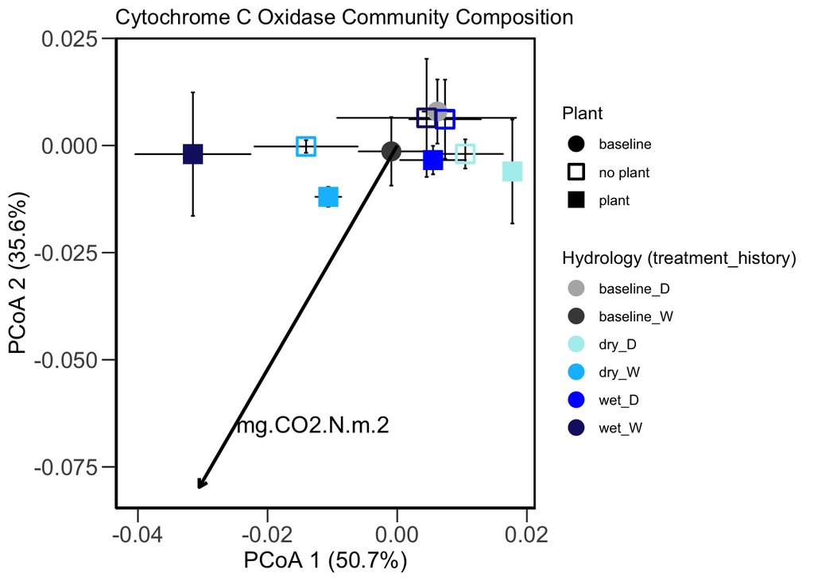

```r
A <-as.list(fit_cytoCox3$vectors)
vec<-as.data.frame(fit_cytoCox3$vectors$arrows*sqrt(fit_cytoCox3$vectors$r)*0.35) #What is this calculation?
p<- as.data.frame(A$pvals)
vec <- cbind(vec, p)
#vec <-  subset(vec, A$pvals<=0.05) #Should I only add the vec if the pval is <= 0.05?

#Plot using ggplot2
df4d <- as.data.frame(pcoa_cytoCox3.cent.dataframe.trts)
plot4d <- ggplot(df4d, aes(x=V1, y=V2, colour=hydro_combined, shape = plant)) + theme_bw()
plot4d + theme(panel.grid.major = element_blank(),
               panel.grid.minor = element_blank(),
               axis.line = element_line(colour = "black")) +
  theme(panel.background = element_blank()) +
  geom_errorbarh(aes(xmax=V1+V1e, xmin=V1-V1e), colour="black") +
  geom_errorbar(aes(ymax=V2+V2e, ymin=V2-V2e), colour="black") +
  geom_point(aes(colour=hydro_combined, shape=plant), size=5, stroke = 1.25, show.legend = TRUE) +
  geom_segment(data=vec, aes(x=0,xend=Dim1,y=0,yend=Dim2), size=1,
      arrow = arrow(length = unit(0.2, "cm")),colour="black",inherit.aes=F)+
  geom_text(data=vec,aes(x=-0.013,y=-0.065,label="mg.CO2.N.m.2"),size=5, inherit.aes=F)+
  scale_colour_manual(labels = c("baseline_D", "baseline_W", "dry_D", "dry_W", "wet_D", "wet_W"),
                      values = c("gray70", "grey28", "paleturquoise", "deepskyblue", "blue", "midnightblue")) +
  scale_shape_manual(labels = c("baseline","no plant","plant"), values = c(16,22,15)) +
  theme(axis.title = element_text(size=14),
        axis.text = element_text(size=14),
        axis.text.x = element_text(size=14),
        panel.border = element_rect(colour = "black", size = 1.25)) +
  theme(axis.ticks.length = unit(0.3, "cm")) +
        xlab("PCoA 1 (50.7%)") + ylab("PCoA 2 (35.6%)") +
        labs(colour = "Hydrology (treatment_history)", shape = "Plant") +
    guides(colour = guide_legend(override.aes = list(pch=16, size = 4)),
           shape = guide_legend(override.aes = list(size = 4)))+
    ggtitle("Cytochrome C Oxidase Community Composition")
```

```r
#ggsave("../figures/CcOcomposition4d.jpg", plot=last_plot(), device=NULL, path=NULL, scale=1, width=7, height=5, dpi=300, limitsize=TRUE)
```